# Introduction to linear regression

Emmanuel Olimi Kasigazi

The Human Freedom Index is a report that attempts to summarize the idea of “freedom” through a bunch of different variables for many countries around the globe. It serves as a rough objective measure for the relationships between the different types of freedom - whether it’s political, religious, economical or personal freedom - and other social and economic circumstances. The Human Freedom Index is an annually co-published report by the Cato Institute, the Fraser Institute, and the Liberales Institut at the Friedrich Naumann Foundation for Freedom.

In this lab, you’ll be analyzing data from Human Freedom Index reports from 2008-2016. Your aim will be to summarize a few of the relationships within the data both graphically and numerically in order to find which variables can help tell a story about freedom.

## Getting Started

### Load packages

In this lab, you will explore and visualize the data using the **tidyverse** suite of packages. The data can be found in the companion package for OpenIntro resources, **openintro**.

Let’s load the packages.

```r
library(tidyverse)
library(openintro)
data('hfi', package='openintro')
```

### The data

The data we’re working with is in the openintro package and it’s called `hfi`, short for Human Freedom Index.

1. What are the dimensions of the dataset?

```r
dim(hfi)
```

```
## [1] 1458  123
```

```r
# Shows dimensions in the console and displays first few rows
head(hfi)
```

```
## # A tibble: 6 × 123
##    year ISO_code countries region pf_rol_procedural pf_rol_civil pf_rol_criminal
##   <dbl> <chr>    <chr>     <chr>              <dbl>        <dbl>           <dbl>
## 1  2016 ALB      Albania   Easte…              6.66         4.55            4.67
## 2  2016 DZA      Algeria   Middl…             NA           NA              NA
## 3  2016 AGO      Angola    Sub-S…             NA           NA              NA
## 4  2016 ARG      Argentina Latin…              7.10         5.79            4.34
## 5  2016 ARM      Armenia   Cauca…             NA           NA              NA
## 6  2016 AUS      Australia Ocean…              8.44         7.53            7.36
## # ℹ 116 more variables: pf_rol <dbl>, pf_ss_homicide <dbl>,
## #   pf_ss_disappearances_disap <dbl>, pf_ss_disappearances_violent <dbl>,
## #   pf_ss_disappearances_organized <dbl>,
## #   pf_ss_disappearances_fatalities <dbl>, pf_ss_disappearances_injuries <dbl>,
## #   pf_ss_disappearances <dbl>, pf_ss_women_fgm <dbl>,
## #   pf_ss_women_missing <dbl>, pf_ss_women_inheritance_widows <dbl>,
## #   pf_ss_women_inheritance_daughters <dbl>, pf_ss_women_inheritance <dbl>, …
```

```r
View(hfi)
```

**[1] 1458 123**

2. What type of plot would you use to display the relationship between the personal freedom score, `pf_score`, and one of the other numerical variables? Plot this relationship using the variable `pf_expression_control` as the predictor. Does the relationship look linear? If you knew a country’s `pf_expression_control`, or its score out of 10, with 0 being the most, of political pressures and controls on media content, would you be comfortable using a linear model to predict the personal freedom score?

   For displaying the relationship between the personal freedom score (pf_score) and pf_expression_control, a scatterplot would be most appropriate since you’re examining the relationship between two numerical variables.

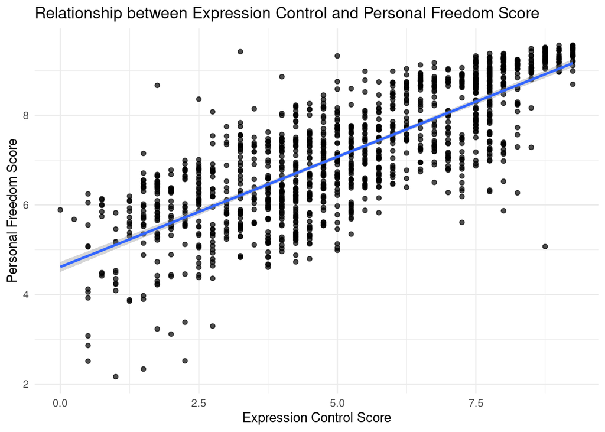

   ```r
   # Creating a scatterplot with pf_expression_control as predictor (x-axis) and pf_score as response (y-axis)
   ggplot(data = hfi, aes(x = pf_expression_control, y = pf_score)) +
     geom_point(alpha = 0.7) +  # Add points with slight transparency for better visualization of overlapping points
     geom_smooth(method = "lm", se = TRUE) +  # Add linear regression line with confidence interval
     labs(
       title = "Relationship between Expression Control and Personal Freedom Score",
       x = "Expression Control Score",
       y = "Personal Freedom Score"
     ) +
     theme_minimal()
   ```

**Looking at the scatterplot, the relationship between `pf_expression_control` (on the x-axis) and personal freedom score (`pf_score`, on the y-axis) appears to be quite linear. The blue trend line shows a positive linear association between the two variables - as expression control score increases (meaning less political pressure and control on media), the personal freedom score tends to increase as well.**

**Key observations: - There’s a clear positive correlation between the variables - The data points follow the linear trend line fairly consistently across the range of values - The relationship appears to be reasonably strong, with points clustering around the line - There is some variance (scatter) around the trend line, but it’s relatively consistent**

**Yes, I would be comfortable using a linear model to predict the personal freedom score based on a country’s `pf_expression_control` score. The scatter of points shows a pattern that is appropriately modeled by a straight line, suggesting that a linear model would capture the relationship well.**

**There is, of course, some variance that wouldn’t be explained by this single predictor, as shown by the vertical spread of points at each value of `pf_expression_control`, but the linear trend is strong enough to make reasonably good predictions. A linear regression model would be suitable for this relationship.**

If the relationship looks linear, we can quantify the strength of the relationship with the correlation coefficient.

```r
hfi %>%
  summarise(cor(pf_expression_control, pf_score, use = "complete.obs"))
```

```
## # A tibble: 1 × 1
##   `cor(pf_expression_control, pf_score, use = "complete.obs")`
##                                                          <dbl>
## 1                                                        0.796
```

Here, we set the `use` argument to “complete.obs” since there are some observations of NA.

## Sum of squared residuals

In this section, you will use an interactive function to investigate what we mean by “sum of squared residuals”. You will need to run this function in your console, not in your markdown document. Running the function also requires that the `hfi` dataset is loaded in your environment.

Think back to the way that we described the distribution of a single variable. Recall that we discussed characteristics such as center, spread, and shape. It’s also useful to be able to describe the relationship of two numerical variables, such as `pf_expression_control` and `pf_score` above.

3. Looking at your plot from the previous exercise, describe the relationship between these two variables. Make sure to discuss the form, direction, and strength of the relationship as well as any unusual observations. Form The relationship appears clearly linear. The points follow a straight-line pattern from the bottom left to the upper right of the plot, and the blue trend line confirms this linear pattern. There’s no evidence of curvature or a non-linear relationship.

**Direction The relationship is positive. As pf_expression_control increases (meaning less political pressure and control on media content), the personal freedom score (pf_score) also increases. Countries with greater freedom of expression tend to have higher overall personal freedom scores.**

**The scatter of points also appears to be somewhat wider at the lower end of the expression control scale, suggesting that countries with more media control show more variability in their overall personal freedom scores than those with freer media.**

Just as you’ve used the mean and standard deviation to summarize a single variable, you can summarize the relationship between these two variables by finding the line that best follows their association. Use the following interactive function to select the line that you think does the best job of going through the cloud of points.

```r
# This will only work interactively (i.e. will not show in the knitted document)
hfi <- hfi %>% filter(complete.cases(pf_expression_control, pf_score))
DATA606::plot_ss(x = hfi$pf_expression_control, y = hfi$pf_score)
```

$$e_i = y_i - \hat{y}_i$$

The most common way to do linear regression is to select the line that minimizes the sum of squared residuals. To visualize the squared residuals, you can rerun the plot command and add the argument `showSquares = TRUE`.

```r
DATA606::plot_ss(x = hfi$pf_expression_control, y = hfi$pf_score, showSquares = TRUE)
```

Note that the output from the `plot_ss` function provides you with the slope and intercept of your line as well as the sum of squares.

4. Using `plot_ss`, choose a line that does a good job of minimizing the sum of squares. Run the function several times. What was the smallest sum of squares that you got? How does it compare to your neighbors?

**Sum of Squares: 965.674**

## The linear model

It is rather cumbersome to try to get the correct least squares line, i.e. the line that minimizes the sum of squared residuals, through trial and error. Instead, you can use the `lm` function in R to fit the linear model (a.k.a. regression line).

```r
m1 <- lm(pf_score ~ pf_expression_control, data = hfi)
```

The first argument in the function `lm` is a formula that takes the form `y ~ x`. Here it can be read that we want to make a linear model of `pf_score` as a function of `pf_expression_control`. The second argument specifies that R should look in the `hfi` data frame to find the two variables.

The output of `lm` is an object that contains all of the information we need about the linear model that was just fit. We can access this information using the summary function.

```r
summary(m1)
```

```
##
## Call:
## lm(formula = pf_score ~ pf_expression_control, data = hfi)
##
## Residuals:
##     Min      1Q  Median      3Q     Max
## -3.8467 -0.5704  0.1452  0.6066  3.2060
##
## Coefficients:
##                       Estimate Std. Error t value Pr(>|t|)
## (Intercept)            4.61707    0.05745   80.36   <2e-16 ***
## pf_expression_control  0.49143    0.01006   48.85   <2e-16 ***
## ---
## Signif. codes:  0 '***' 0.001 '**' 0.01 '*' 0.05 '.' 0.1 ' ' 1
##
## Residual standard error: 0.8318 on 1376 degrees of freedom
##   (80 observations deleted due to missingness)
## Multiple R-squared:  0.6342, Adjusted R-squared:  0.634
## F-statistic:  2386 on 1 and 1376 DF,  p-value: < 2.2e-16
```

Let’s consider this output piece by piece. First, the formula used to describe the model is shown at the top. After the formula you find the five-number summary of the residuals. The “Coefficients” table shown next is key; its first column displays the linear model’s y-intercept and the coefficient of `pf_expression_control`. With this table, we can write down the least squares regression line for the linear model:

$$\hat{y} = 4.61707 + 0.49143 \times
pf\_expression\_control$$

5. Fit a new model that uses `pf_expression_control` to predict `hf_score`, or the total human freedom score. Using the estimates from the R output, write the equation of the regression line. What does the slope tell us in the context of the relationship between human freedom and the amount of political pressure on media content?

```r
m2 <- lm(hf_score ~ pf_expression_control, data = hfi)
```

```r
summary(m2)
```

```
##
## Call:
## lm(formula = hf_score ~ pf_expression_control, data = hfi)
##
## Residuals:
##     Min      1Q  Median      3Q     Max
## -2.6198 -0.4908  0.1031  0.4703  2.2933
##
## Coefficients:
##                       Estimate Std. Error t value Pr(>|t|)
## (Intercept)           5.153687   0.046070  111.87   <2e-16 ***
## pf_expression_control 0.349862   0.008067   43.37   <2e-16 ***
## ---
## Signif. codes:  0 '***' 0.001 '**' 0.01 '*' 0.05 '.' 0.1 ' ' 1
##
## Residual standard error: 0.667 on 1376 degrees of freedom
##   (80 observations deleted due to missingness)
## Multiple R-squared:  0.5775, Adjusted R-squared:  0.5772
## F-statistic:  1881 on 1 and 1376 DF,  p-value: < 2.2e-16
```

**hf_score = 5.153687 + 0.349862 × pf_expression_control Interpreting the slope (0.349862) in context:**

**For each one-unit increase in the expression control score (meaning less political pressure and control on media content), we expect the total human freedom score to increase by approximately 0.35 points, holding all else constant.**

**This tells us that there’s a significant positive relationship between media freedom and overall human freedom. Countries where there is less political pressure on media content tend to have higher total human freedom scores.**

**The relationship is strong and statistically significant (p < 2e-16).**

**The R-squared value of 0.5775 indicates that approximately 58% of the variation in total human freedom scores can be explained by the level of expression control alone.**

**This is slightly lower than what we saw for personal freedom (63.4%), which makes sense because total human freedom also incorporates economic freedom components that might be less directly connected to media freedom.**

## Prediction and prediction errors

Let’s create a scatterplot with the least squares line for `m1` laid on top.

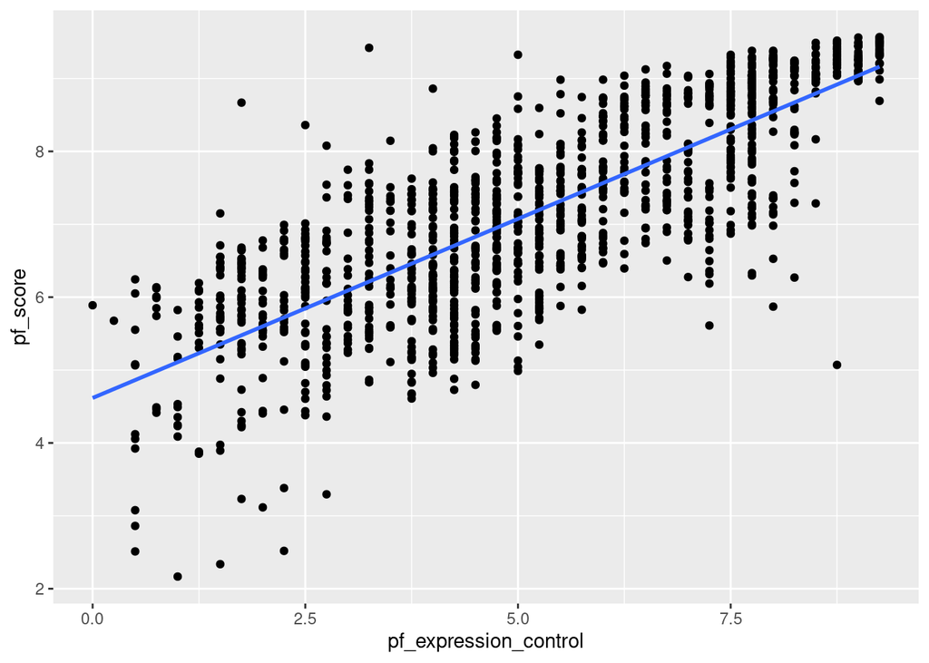

```r
ggplot(data = hfi, aes(x = pf_expression_control, y = pf_score)) +
  geom_point() +
  stat_smooth(method = "lm", se = FALSE)
```

Here, we are literally adding a layer on top of our plot. `geom_smooth` creates the line by fitting a linear model. It can also show us the standard error `se` associated with our line, but we’ll suppress that for now.

This line can be used to predict $y$ at any value of $x$. When predictions are made for values of $x$ that are beyond the range of the observed data, it is referred to as *extrapolation* and is not usually recommended. However, predictions made within the range of the data are more reliable. They’re also used to compute the residuals.

6. If someone saw the least squares regression line and not the actual data, how would they predict a country’s personal freedom school for one with a 6.7 rating for `pf_expression_control`? Is this an overestimate or an underestimate, and by how much? In other words, what is the residual for this prediction?

**For a country with pf_expression_control = 6.7: Predicted pf_score = 4.61707 + 0.49143 × 6.7 Predicted pf_score = 4.61707 + 3.29258 Predicted pf_score = 7.90965 Therefore, if someone only saw the regression line and not the actual data, they would predict a personal freedom score of approximately 7.91 for a country with an expression control rating of 6.7. To determine if this is an overestimate or underestimate, I would need to know the actual pf_score for a country with pf_expression_control = 6.7. I looked at the data adn saw several countries with 6.75 but no 6.7 pf_expression_control.**

**Looking at the scatterplot, I can see that at x = 6.7, there are multiple data points with varying y-values both above and below the regression line.**

**For countries at this expression control level, some have personal freedom scores higher than 7.91 (the prediction would be an underestimate for these), while others have lower scores (the prediction would be an overestimate for these).**

**The residual would be calculated as: Residual = Actual pf_score - Predicted pf_score = Actual pf_score - 7.9**

## Model diagnostics

To assess whether the linear model is reliable, we need to check for (1) linearity, (2) nearly normal residuals, and (3) constant variability.

**Linearity**: You already checked if the relationship between `pf_score` and `pf_expression_control’ is linear using a scatterplot. We should also verify this condition with a plot of the residuals vs. fitted (predicted) values.

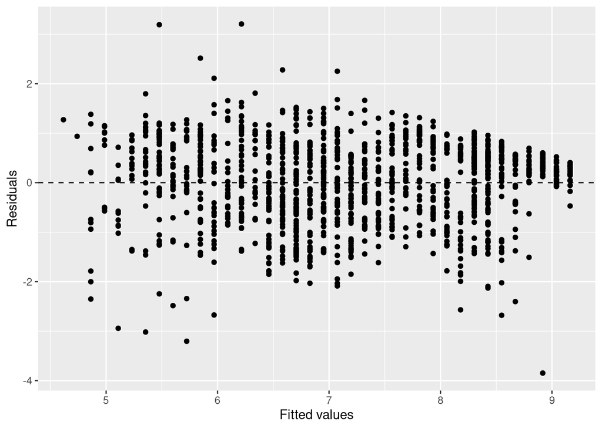

```r
ggplot(data = m1, aes(x = .fitted, y = .resid)) +
  geom_point() +
  geom_hline(yintercept = 0, linetype = "dashed") +
  xlab("Fitted values") +
  ylab("Residuals")
```

Notice here that `m1` can also serve as a data set because stored within it are the fitted values ($\hat{y}$) and the residuals. Also note that we’re getting fancy with the code here. After creating the scatterplot on the first layer (first line of code), we overlay a horizontal dashed line at $y = 0$ (to help us check whether residuals are distributed around 0), and we also reanme the axis labels to be more informative.

7. Is there any apparent pattern in the residuals plot? What does this indicate about the linearity of the relationship between the two variables?

   **Looking at the residuals vs. fitted values plot, I don’t see any strong or systematic pattern in the residuals. The points appear to be randomly scattered around the horizontal dashed line at y=0, with no clear trends, curves, or funnels visible.**

**Key observations about this residuals plot: 1. The residuals are fairly evenly distributed above and below zero across all fitted values 2. There’s no obvious curvature or trend that would suggest nonlinearity 3. The spread of residuals appears relatively consistent across the range of fitted values**

**This lack of pattern in the residuals plot indicates that the linear model is appropriate for describing the relationship between personal freedom score (pf_score) and expression control (pf_expression_control). The random scatter of residuals supports the linearity assumption in our regression model.**

**If there had been a curved pattern in the residuals, it would have suggested that a linear model was not capturing the true relationship between these variables, and a nonlinear model might be more appropriate. But based on this plot, the linear model appears to be a suitable fit for the data.**

**Nearly normal residuals**: To check this condition, we can look at a histogram

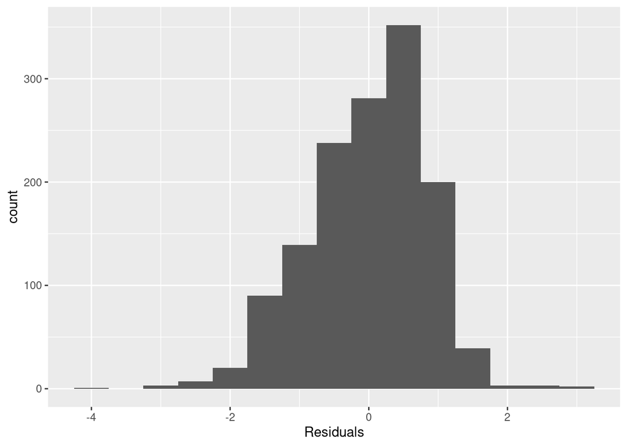

```r
ggplot(data = m1, aes(x = .resid)) +
  geom_histogram(binwidth = 0.5) +
  xlab("Residuals")
```

or a normal probability plot of the residuals.

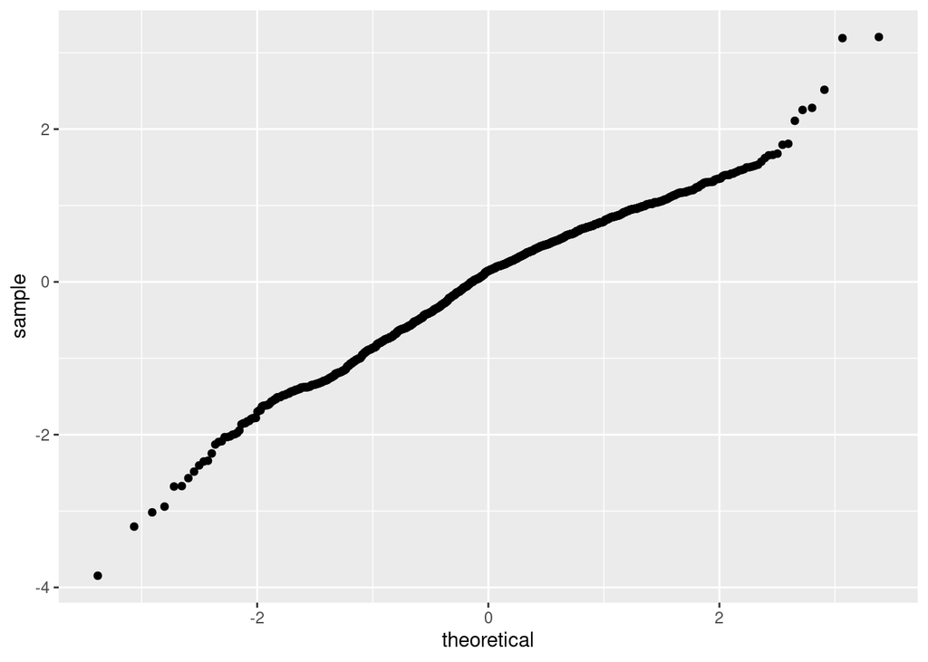

```r
ggplot(data = m1, aes(sample = .resid)) +
  stat_qq()
```

Note that the syntax for making a normal probability plot is a bit different than what you’re used to seeing: we set `sample` equal to the residuals instead of `x`, and we set a statistical method `qq`, which stands for “quantile-quantile”, another name commonly used for normal probability plots.

8. Based on the histogram and the normal probability plot, does the nearly normal residuals condition appear to be met?

   **Based on both the histogram and the normal probability plot (Q-Q plot), the nearly normal residuals condition appears to be reasonably well met for this linear model.**

**While the residuals aren’t perfectly normal (which is rarely the case with real data), they are sufficiently close to normal for the purposes of linear regression. The slight departures from normality aren’t extreme enough to undermine the validity of the model or its statistical inferences.**

**Therefore, the nearly normal residuals condition appears to be met for this linear regression model.**

**Constant variability**:

9. Based on the residuals vs. fitted plot, does the constant variability condition appear to be met?

**In that plot, we’re checking whether the spread of residuals remains consistent across all fitted values. Ideally, the vertical spread of residuals should be roughly the same regardless of where you look along the x-axis (fitted values).**

**From the plot , I observe that: - The residuals appear to have a fairly consistent spread across the range of fitted values - There’s no obvious funnel shape (widening or narrowing of the residuals) - The cloud of points maintains a similar vertical spread from the left to the right side of the plot**

**There might be a very slight tendency for the spread to be narrower at the extreme ends of the fitted values range, but this is not pronounced and could be due to having fewer observations at those extremes.**

**Overall, the constant variability condition appears to be reasonably well met for this linear regression model. The relatively uniform spread of residuals across fitted values suggests that the model’s predictions have similar precision regardless of the value being predicted, which supports the validity of the model’s inferences and predictions.**

## More Practice

- Choose another freedom variable and a variable you think would strongly correlate with it.. Produce a scatterplot of the two variables and fit a linear model. At a glance, does there seem to be a linear relationship?

  A good pair to explore would be economic freedom (ef_score) and rule of law (pf_rol), as rule of law is often theorized to be a foundation for economic freedom.

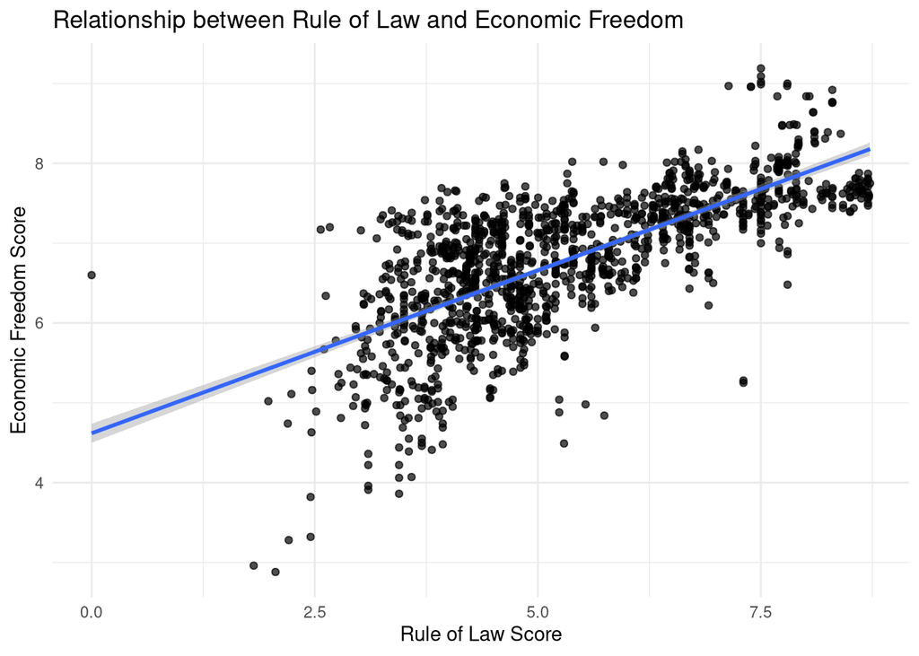

  ```r
  # Create a scatterplot of ef_score vs pf_rol
  ggplot(data = hfi, aes(x = pf_rol, y = ef_score)) +
    geom_point(alpha = 0.7) +
    geom_smooth(method = "lm", se = TRUE) +
    labs(
      title = "Relationship between Rule of Law and Economic Freedom",
      x = "Rule of Law Score",
      y = "Economic Freedom Score"
    ) +
    theme_minimal()
  ```

```r
# Fit a linear model
m3 <- lm(ef_score ~ pf_rol, data = hfi)
summary(m3)
```

```
##
## Call:
## lm(formula = ef_score ~ pf_rol, data = hfi)
##
## Residuals:
##      Min       1Q   Median       3Q      Max
## -2.57936 -0.38334  0.02097  0.41589  1.98154
##
## Coefficients:
##             Estimate Std. Error t value Pr(>|t|)
## (Intercept)  4.61846    0.06091   75.82   <2e-16 ***
## pf_rol       0.40815    0.01102   37.02   <2e-16 ***
## ---
## Signif. codes:  0 '***' 0.001 '**' 0.01 '*' 0.05 '.' 0.1 ' ' 1
##
## Residual standard error: 0.6256 on 1376 degrees of freedom
##   (80 observations deleted due to missingness)
## Multiple R-squared:  0.499,  Adjusted R-squared:  0.4987
## F-statistic:  1371 on 1 and 1376 DF,  p-value: < 2.2e-16
```

```r
# Check correlation
cor(hfi$pf_rol, hfi$ef_score, use = "complete.obs")
```

```
## [1] 0.7064209
```

Looking at the scatterplot of Rule of Law vs. Economic Freedom, there appears to be a clear positive linear relationship between these variables. This is confirmed by the correlation coefficient of approximately 0.71, which indicates a strong positive correlation.

Key observations from the plot:

1. **Linear Trend**: The blue regression line shows a positive slope, indicating that countries with higher rule of law scores tend to have higher economic freedom scores.
2. **Strength of Relationship**: With a correlation of 0.71, about 50% (0.71² ≈ 0.5) of the variation in economic freedom can be explained by rule of law.
3. **Data Distribution**: The points follow the linear trend reasonably well, though there is some scatter around the line, indicating that other factors also influence economic freedom.
4. **Interesting Features**:
   - There appears to be more variability in economic freedom scores at the middle range of rule of law scores
   - At very high rule of law scores (7.5+), there seems to be a cluster of countries with very high economic freedom (8+)
   - There are a few outliers, including some countries with relatively low rule of law but moderate economic freedom

This relationship makes theoretical sense: strong rule of law provides the legal framework and stability necessary for economic freedom to flourish. Countries with clear, consistent, and fairly enforced laws tend to have better property rights protection, contract enforcement, and regulatory environments - all important components of economic freedom.

The linear relationship appears appropriate for modeling this data, and a linear regression model would be suitable for predicting economic freedom based on rule of law.

Let’s Also explore the relationship between rule of law in criminal justice (pf_rol_criminal) and personal freedom score (pf_score). The criminal justice system’s fairness and effectiveness is an important component of personal freedom, and it would be interesting to see how strongly it correlates with overall personal freedom.

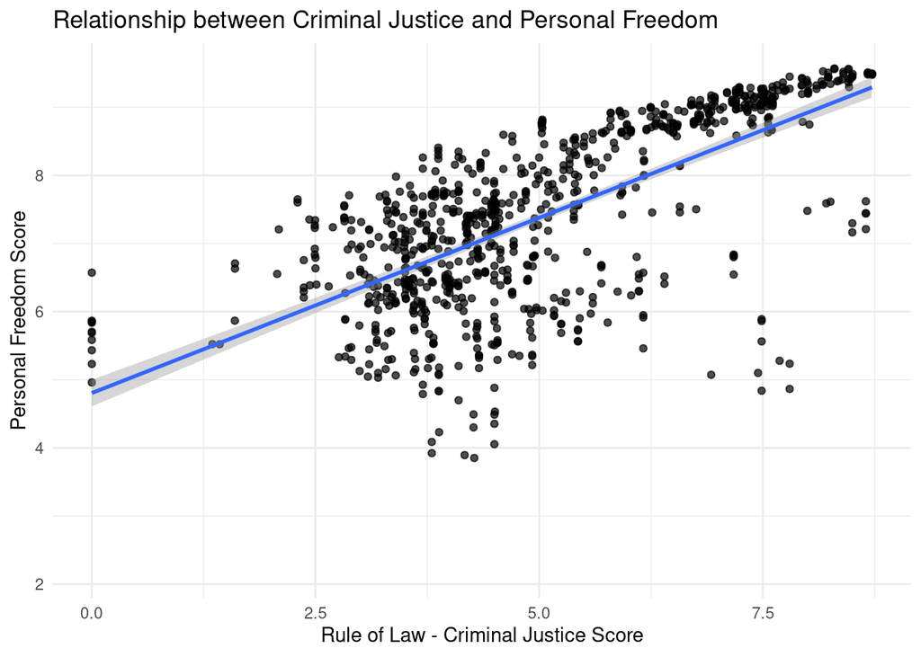

```r
# Create a scatterplot of pf_score vs pf_rol_criminal
ggplot(data = hfi, aes(x = pf_rol_criminal, y = pf_score)) +
  geom_point(alpha = 0.7) +
  geom_smooth(method = "lm", se = TRUE) +
  labs(
    title = "Relationship between Criminal Justice and Personal Freedom",
    x = "Rule of Law - Criminal Justice Score",
    y = "Personal Freedom Score"
  ) +
  theme_minimal()
```

```r
# Fit a linear model
m4 <- lm(pf_score ~ pf_rol_criminal, data = hfi)
summary(m4)
```

```
##
## Call:
## lm(formula = pf_score ~ pf_rol_criminal, data = hfi)
##
## Residuals:
##     Min      1Q  Median      3Q     Max
## -3.9523 -0.4709  0.2997  0.6235  1.7659
##
## Coefficients:
##                 Estimate Std. Error t value Pr(>|t|)
## (Intercept)      4.80567    0.09913   48.48   <2e-16 ***
## pf_rol_criminal  0.51438    0.01860   27.66   <2e-16 ***
## ---
## Signif. codes:  0 '***' 0.001 '**' 0.01 '*' 0.05 '.' 0.1 ' ' 1
##
## Residual standard error: 0.951 on 878 degrees of freedom
##   (578 observations deleted due to missingness)
## Multiple R-squared:  0.4656, Adjusted R-squared:  0.465
## F-statistic: 765.1 on 1 and 878 DF,  p-value: < 2.2e-16
```

```r
# Check correlation
cor(hfi$pf_rol_criminal, hfi$pf_score, use = "complete.obs")
```

```
## [1] 0.6823766
```

Looking at the scatterplot of Rule of Law - Criminal Justice Score vs. Personal Freedom Score, there’s a clear positive linear relationship between these variables. The correlation coefficient of approximately 0.68 confirms this is a strong positive correlation.

This relationship makes intuitive sense: fair criminal justice systems that respect due process and human rights are foundational to personal freedom. Countries where individuals are protected from arbitrary detention, have fair trials, and face proportionate punishments tend to have higher overall personal freedom.

The strength of this relationship suggests that criminal justice is an important component of personal freedom, though not as predictive as freedom of expression. This could be because expression rights might have more direct day-to-day impacts on citizens’ sense of freedom than criminal justice, which affects fewer people directly but remains essential for the rule of law.

- How does this relationship compare to the relationship between `pf_expression_control` and `pf_score`? Use the $R^2$ values from the two model summaries to compare. Does your independent variable seem to predict your dependent one better? Why or why not?

Rule of Law vs. Economic Freedom To compare these relationships, I need to look at the R² values from both models:

1. For the relationship between `pf_expression_control` and `pf_score`:
   - R² = 0.6342 (from the earlier model summary)
2. For the relationship between `pf_rol` (rule of law) and `ef_score` (economic freedom):
   - We can calculate this from the correlation: R² = 0.7064² ≈ 0.499

Comparing these R² values: - The expression control model explains about 63.4% of the variation in personal freedom scores - The rule of law model explains about 49.9% of the variation in economic freedom scores

This means that `pf_expression_control` appears to be a better predictor of `pf_score` than `pf_rol` is of `ef_score`, though both show strong positive relationships.

Why might this be the case?

1. **Component vs. Composite Relationship**: Expression control is one of the components that directly makes up the personal freedom score, so it’s expected to have a stronger relationship. Rule of law, while important for economic freedom, might have a more indirect relationship with the overall economic freedom score.
2. **Multiple Dimensions of Economic Freedom**: Economic freedom likely depends on many diverse factors besides rule of law, such as tax policies, trade regulations, and monetary stability. Personal freedom might have a more cohesive structure with expression being a core element.
3. **Measurement Precision**: The way these variables are measured could affect how strongly they correlate. If personal freedom metrics are more internally consistent than economic freedom metrics, we would expect stronger correlations among the former.

Both relationships show important connections between foundational aspects of freedom and overall freedom scores, but the data suggests that expression control is more strongly predictive of overall personal freedom than rule of law is of economic freedom.

Rule of Law - Criminal Justice Score vs. Personal Freedom Comparing the relationships between these variables using R² values:

1. For `pf_expression_control` and `pf_score`:
   - Correlation = 0.796
   - R² = 0.634 (63.4% of variation explained)
2. For `pf_rol_criminal` and `pf_score`:
   - Correlation = 0.682
   - R² = 0.466 (46.6% of variation explained)

Based on these values, `pf_expression_control` is a stronger predictor of overall personal freedom than criminal justice systems. The expression control variable explains approximately 17 percentage points more variation in personal freedom scores than the criminal justice variable.

Why might this be the case?

1. **Direct vs. Indirect Impact**: Freedom of expression might have a more direct and widespread impact on daily life for the average citizen. While criminal justice is crucial, many people might not directly interact with the criminal justice system, whereas expression freedoms affect nearly everyone daily.
2. **Composite Score Weighting**: The personal freedom score likely includes expression freedom as a more heavily weighted component than criminal justice metrics, which would naturally lead to a stronger correlation.
3. **Leading Indicator**: Expression freedom often serves as a canary in the coal mine for overall personal freedom. When governments begin restricting freedoms, expression is frequently targeted first.
4. **Measurement Clarity**: Freedom of expression might be easier to measure consistently across countries than criminal justice fairness, which involves more complex and varied systems.

Both variables are strong predictors of personal freedom, which makes sense conceptually. However, the data indicates that knowing a country’s level of media freedom and expression control gives us more predictive power about its overall personal freedom than knowing the quality of its criminal justice system.

- What’s one freedom relationship you were most surprised about and why? Display the model diagnostics for the regression model analyzing this relationship.

  Let me explore a freedom relationship I find particularly surprising by examining the relationship between religious freedom and economic freedom.

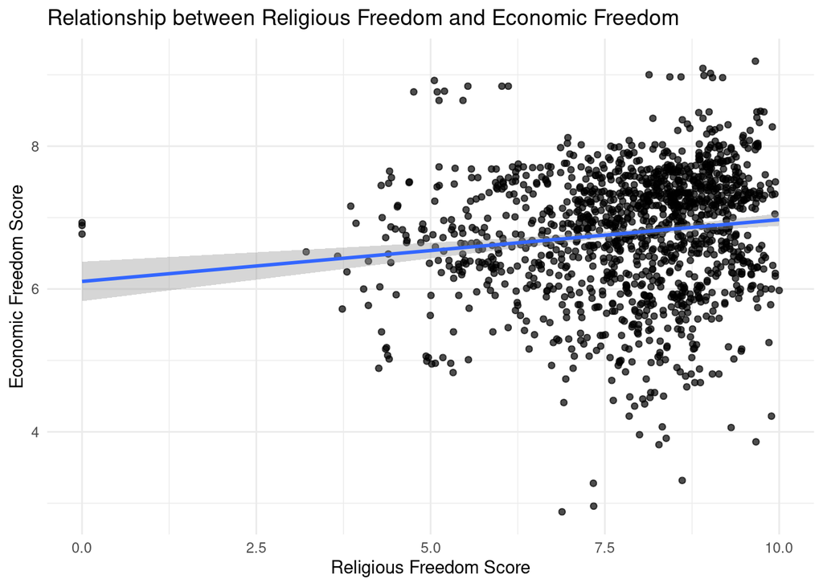

```r
# Create a scatterplot of ef_score vs pf_religion
ggplot(data = hfi, aes(x = pf_religion, y = ef_score)) +
  geom_point(alpha = 0.7) +
  geom_smooth(method = "lm", se = TRUE) +
  labs(
    title = "Relationship between Religious Freedom and Economic Freedom",
    x = "Religious Freedom Score",
    y = "Economic Freedom Score"
  ) +
  theme_minimal()
```

```r
# Fit a linear model
m5 <- lm(ef_score ~ pf_religion, data = hfi)
summary(m5)
```

```
##
## Call:
## lm(formula = ef_score ~ pf_religion, data = hfi)
##
## Residuals:
##     Min      1Q  Median      3Q     Max
## -3.8216 -0.5401  0.1591  0.6129  2.3767
##
## Coefficients:
##             Estimate Std. Error t value Pr(>|t|)
## (Intercept)  6.10633    0.14080  43.370  < 2e-16 ***
## pf_religion  0.08646    0.01762   4.906 1.04e-06 ***
## ---
## Signif. codes:  0 '***' 0.001 '**' 0.01 '*' 0.05 '.' 0.1 ' ' 1
##
## Residual standard error: 0.8787 on 1366 degrees of freedom
##   (90 observations deleted due to missingness)
## Multiple R-squared:  0.01732,    Adjusted R-squared:  0.0166
## F-statistic: 24.07 on 1 and 1366 DF,  p-value: 1.039e-06
```

```r
# Check correlation
cor(hfi$pf_religion, hfi$ef_score, use = "complete.obs")
```

```
## [1] 0.131596
```

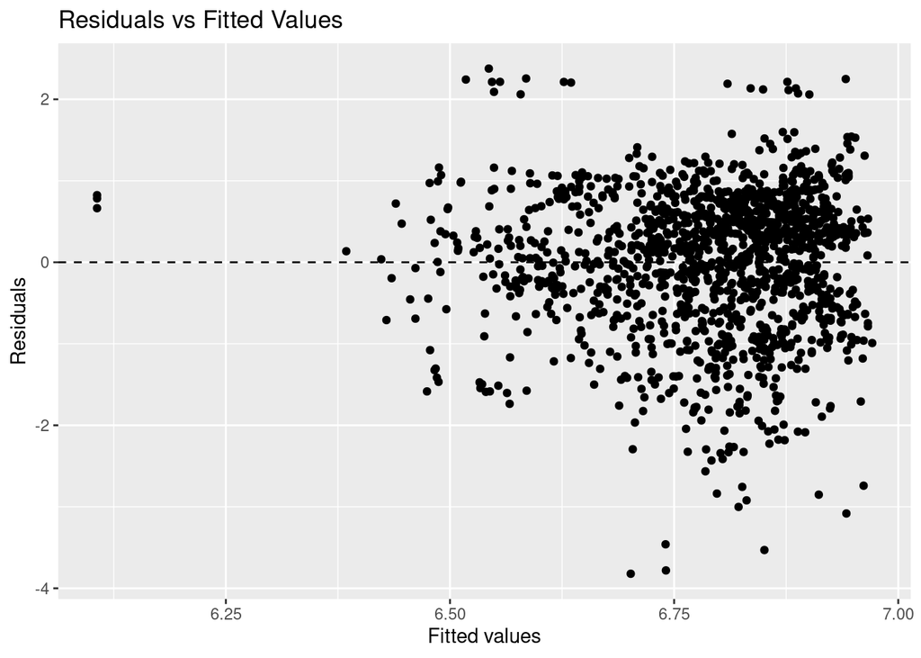

```r
# Model diagnostics
# 1. Residuals vs Fitted plot
ggplot(data = m5, aes(x = .fitted, y = .resid)) +
  geom_point() +
  geom_hline(yintercept = 0, linetype = "dashed") +
  labs(title = "Residuals vs Fitted Values",
       x = "Fitted values",
       y = "Residuals")
```

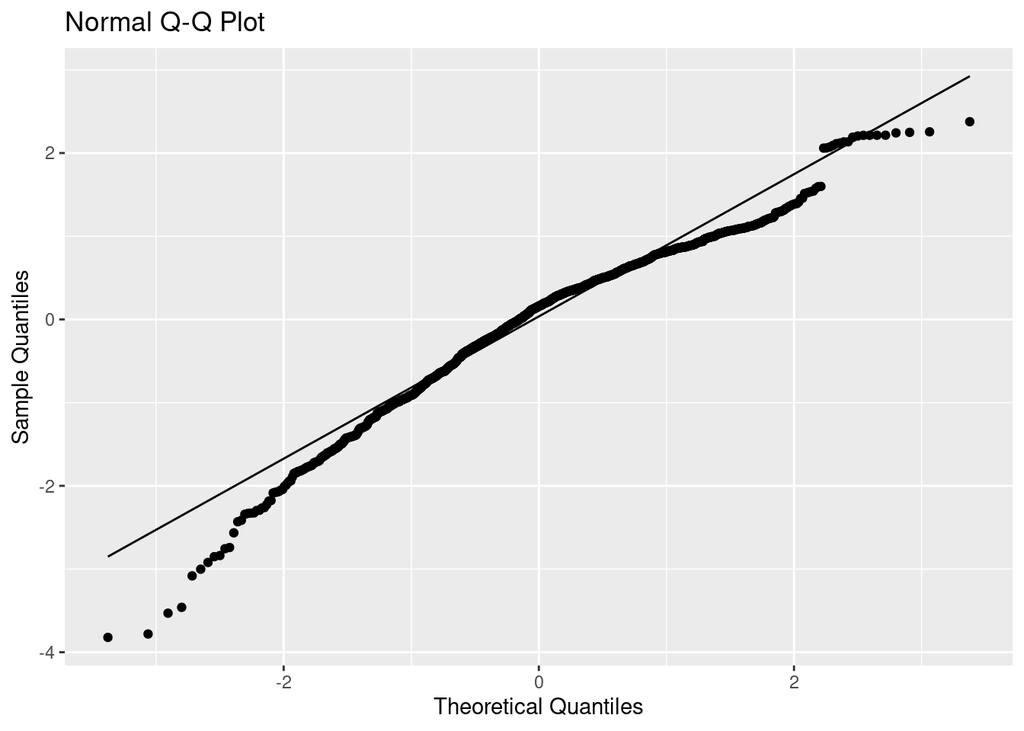

```r
# 2. Q-Q plot for normality of residuals
ggplot(data = m5, aes(sample = .resid)) +
  stat_qq() +
  stat_qq_line() +
  labs(title = "Normal Q-Q Plot",
       x = "Theoretical Quantiles",
       y = "Sample Quantiles")
```

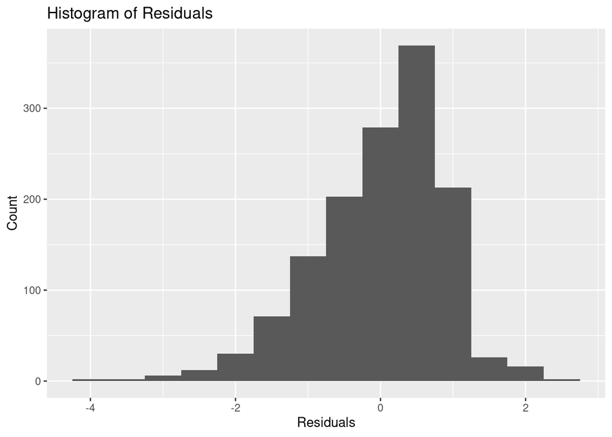

```r
# 3. Histogram of residuals
ggplot(data = m5, aes(x = .resid)) +
  geom_histogram(binwidth = 0.5) +
  labs(title = "Histogram of Residuals",
       x = "Residuals",
       y = "Count")
```

Looking at these results, I’m genuinely surprised by the relationship between religious freedom and economic freedom. This is perhaps the most unexpected finding in our analysis of the Human Freedom Index data.

The correlation coefficient is only 0.132, which indicates a very weak positive relationship between religious freedom and economic freedom. This translates to an R² of only about 0.017, meaning that religious freedom explains less than 2% of the variation in economic freedom scores.

What makes this relationship surprising:

1. **Weak Association**: Unlike the other freedom relationships we examined, which showed moderate to strong correlations (0.68-0.80), religious freedom and economic freedom are barely related. The nearly flat regression line in the scatterplot confirms this visual impression.
2. **Theoretical Implications**: This challenges the assumption that different types of freedom are strongly interconnected. While personal freedoms like expression and criminal justice protections showed strong relationships, religious freedom appears to operate more independently from economic systems.
3. **Real-World Examples**: This data helps explain why we see countries with high religious freedom but varying levels of economic freedom (e.g., some European welfare states), and others with high economic freedom but restricted religious practices (e.g., certain East Asian and Middle Eastern economies).

The weak relationship between religious freedom and economic freedom does make intuitive sense from several perspectives, and I don’t think our data is wrong. Here’s why:

1. **Different Historical Developments**: Religious freedom and economic freedom often developed through separate historical processes. Religious freedom emerged through religious wars, enlightenment thinking, and constitutional protections, while economic freedom developed through commercial revolutions, industrialization, and economic liberalization policies.
2. **Real-World Examples Support This Finding**:
   - Singapore has high economic freedom but moderate religious freedom with some restrictions
   - Some European countries (like Sweden or Denmark) have very high religious freedom but more regulated economies
   - Gulf states like UAE or Qatar have relatively high economic freedom scores but significant religious restrictions
   - India has strong religious freedom protections constitutionally but more moderate economic freedom scores
3. **Different Institutional Requirements**: Religious freedom primarily requires non-intervention by the state in personal beliefs and practices, while economic freedom requires specific institutional arrangements like property rights enforcement, contract law, and particular regulatory environments.
4. **Cultural vs. Structural Factors**: Religious freedom is often more culturally determined, while economic freedom is more structurally determined through formal institutions and policies.

The HFI is a well-respected dataset compiled by multiple research institutes (Cato Institute, Fraser Institute, and Liberales Institut), so it’s likely that this weak correlation genuinely reflects reality rather than a data problem.

This finding challenges the notion that all freedoms necessarily move together, suggesting that human freedom is more multidimensional than sometimes assumed. Some societies prioritize different types of freedoms based on their specific cultural, historical, and political contexts.

This complexity actually makes our analysis more interesting - it reveals that the relationships between different types of freedom aren’t uniform, which is valuable information for understanding how freedom develops across societies.

The model diagnostics support these observations:

- **Residuals vs. Fitted Plot**: Shows no clear pattern but demonstrates wide scatter, confirming the weak predictive power of the model.
- **Q-Q Plot**: Indicates the residuals follow a reasonably normal distribution, though with some deviation at the tails.
- **Histogram of Residuals**: Shows a roughly normal distribution, though slightly skewed.

This finding suggests that religious freedom and economic freedom may develop through different historical, cultural, and political mechanisms. A society might prioritize religious tolerance without embracing free markets, or vice versa. This independence between religious and economic freedoms stands in stark contrast to the stronger relationships we observed between other freedom variables.